# Incarceration

Cammi Pham

2022-11-09

## Abstract

This report exposes **patterns of inequality** in incarceration data through data wrangling and data visualizations. The issue this report will focus on is the unfair treatment of people of color and the unjust system/structures that lead to the unfair treatment. This issue is important because the iSchool has a very diverse body of students, so any student/faculty member could be affected by these patterns of inequality.

## Section 1: Introduction

This report will analyze data on **incarceration**. The data used in this report has been collected by the *Vera Institute.* The data I will use is titled *incarceration_trends.csv,* which can be found on the Vera Institute’s Github repository. The data collected contains detailed variables about the population and jail population in each state, along with the counties in each state. The Vera Institute collected this data because it has the goal of disrupting and terminating unjust, racist systems that affect unjust criminalization of immigrants, people of color, and the economically disadvantaged. By using the data collected by the Vera Institute, I will use data analysis and visualization skills to display patterns of inequality in the data. One main pattern that is expected to be revealed in the data is the disproportionate incarceration of people of color. There are many different factors that lead to this issue, which all stem from **racism** and prejudice.

## Section 2: Data Summary

In the data, I have found three values and answer these questions:

- Which race has the highest jail proportion as of the most recent year?

I created a function called highest_race(), which calculated the race with the highest prison proportion in the United States. Instead of finding the race with the highest prison population, I decided to work with proportions since there is not an equal distribution of residents of different races in each state. The main benefit of using proportions is that proportions take population difference into account. The highest_race() function found that Black individuals had the highest jail proportion.

```r
highest_race()
```

```
## [1] "black_prop"
```

- Which state has the highest jail proportion of the race found in the last question?

Using the result from the question above, I created the highest_state() function to find the state with the highest proportion of Black people in jail. The result showed that Wyoming was the state with the highest Black jail proportion.

```r
highest_state()
```

```
## [1] "WY"
```

- What county in the state found above has the highest jail proportion of black individuals?

In the question above, the results showed that Wyoming had the highest proportion of Black people in jail. To dig deeper, I created another function that found the county in Wyoming with the highest proportion, which came out to be Campbell County. After doing further research, I found that Campbell County is one of the counties with the lowest average income in Wyoming.

```r
highest_county()
```

```
## [1] "Campbell County"
```

## Section 3: Growth of the U.S. Prison Population

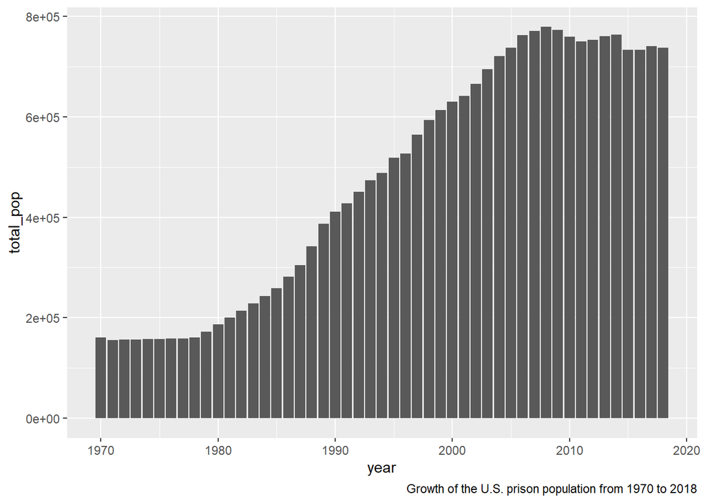

This bar chart shows the growth of the U.S. prison population from the year 1970 to 2018. By looking at the bar chart, you can see that the prison population remains stable from 1970 to around 1978, before the bars on the graph gradually increase from 1980 and never decreases until 2008.

## Section 4: Growth of Prison Population by State

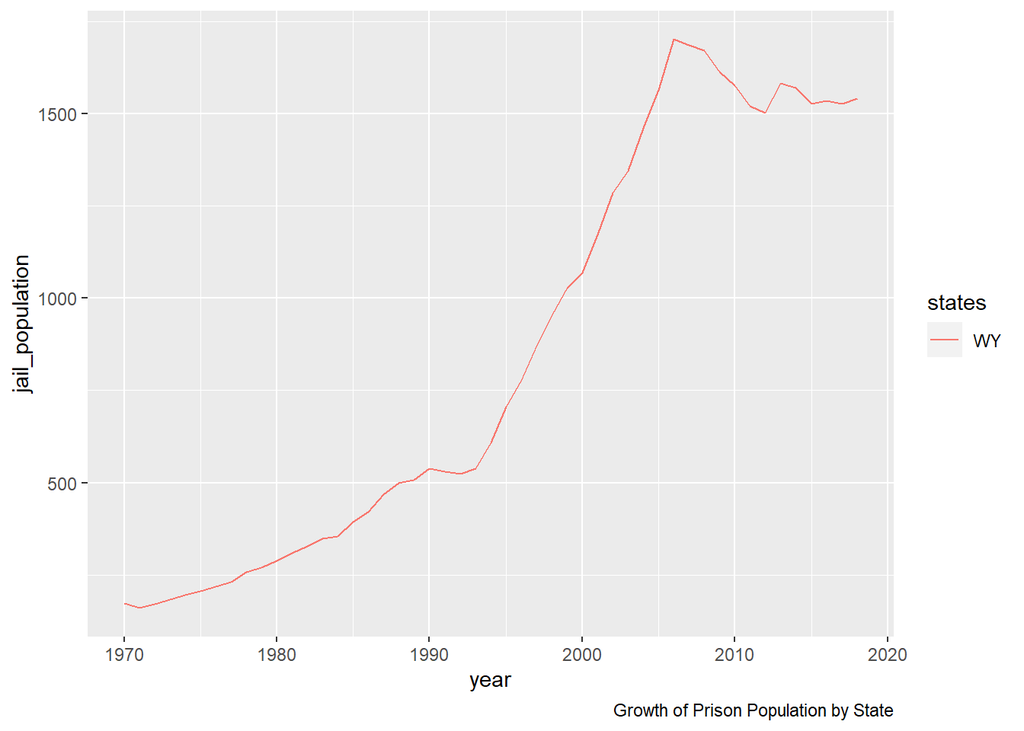

This line chart shows the growth of the U.S. prison population from 1970 to 2018 for specific states. Currently, the state included in the line chart is Wyoming. By looking at the chart, you can see that there is an increase in the prison population between the years 1970 and 1990. Then, there is a small decrease from 1990 to around 1993, before a large increase.

## Section 5: Comparison of Jail Proportions in Each Region

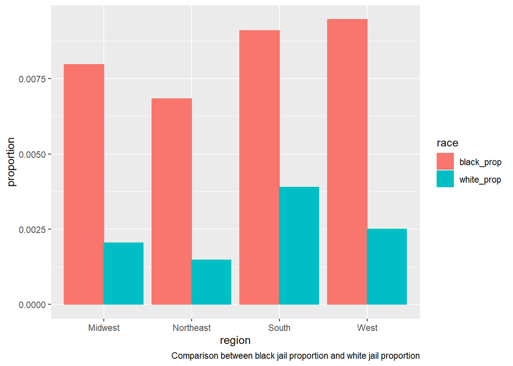

This grouped bar chart compares the jail proportion of Black and White people in each region. The graph clearly shows that in every region, there is a higher proportion of Black individuals in jail compared to White individuals. In the West, 0.9% of Black people are incarcerated, while 0.2% of White people are incarcerated.

## Section 6:

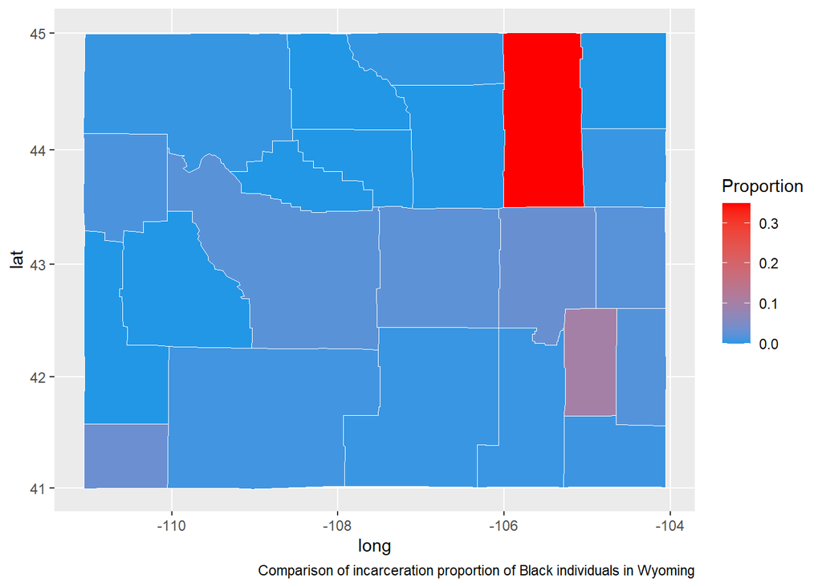

This map displays the counties in Wyoming. It answers the question: what county in Wyoming has the highest proportion of incarcerated Black individuals? The map displays counties in a range of colors from blue to red. Counties in blue have a low proportion of incarcerated black people, and red represents a high proportion. The map shows that Campbell County has the highest proportion, which was also shown in section 2 with simple data wrangling.